# Oil Price Prediction

Sarvesh Naik

2025-02-14

## Objective

To provide one day ahead probabilistic forecast (not a point forecast) for the oil prices. The requirement is to use the gamlss package in R (https://cran.r-project.org/web/packages/gamlss/gamlss.pdf) to forecast the probability distribution of the oil prices, where the variable “OILPRICE” is the response variable.

## The Oil Dataset

The oil dataset in R contains daily prices of the front month WTI (West Texas Intermediate) oil contract traded on the New York Mercantile Exchange (NYMEX). This dataset is used to analyze and model the factors influencing oil prices by examining other financially traded products.

#### Structure and Format

- The dataset is a data frame with 1000 observations and 25 variables.
- The response variable is **OILPRICE**, which represents the log price of the front month WTI oil contract. This contract, denoted as CL1, is the shortest-duration futures contract available for purchase on NYMEX.

#### Key Variables

1. **OILPRICE:**
   - The log price of the front month WTI oil contract (CL1).
   - This is the dependent variable (response) that we’re trying to model and predict.
2. **CL2_log to CL15_log:**
   - These are the log prices of WTI oil contracts for 2 to 15 months ahead.
   - For example, CL2_log corresponds to the contract for delivery two months from the current month.
   - These represent the oil futures curve, showing how market expectations about future oil prices evolve over time.
3. **BDIY_log:**
   - Baltic Dry Index (BDI) – measures the cost of shipping raw materials by sea.
   - It is an indicator of global supply chain demand and economic activity.
4. **SPX_log:**
   - The S&P 500 Index, representing the stock performance of 500 large companies in the U.S.
   - Used to gauge overall market sentiment and economic conditions.
5. **DX1_log:**
   - The US Dollar Index, which tracks the value of the U.S. dollar against a basket of other major currencies.
   - Since oil is traded in USD, fluctuations in the dollar’s value can impact oil prices.
6. **GC1_log:**
   - The log price of the front month gold contract on NYMEX.
   - Gold is often considered a safe-haven asset, and its price movements can reflect risk sentiment.
7. **HO1_log:**
   - The log price of the front month heating oil contract on NYMEX.
   - Used to analyze the relationship between energy products.
8. **USCI_log:**
   - The United States Commodity Index, representing a broad measure of commodity prices.
9. **GNR_log:**
   - The S&P Global Natural Resources Index, which tracks companies involved in natural resources.
10. **SHCOMP_log:**
    - The Shanghai Stock Exchange Composite Index, representing Chinese stock market performance.
    - Useful for assessing global economic dynamics influencing oil demand.
11. **FTSE_log:**
    - The FTSE 100 Index, reflecting the performance of the largest companies listed on the London Stock Exchange.
12. **respLAG:**
    - The lag 1 of OILPRICE, showing the previous day’s log price.
    - This is used to model autoregressive behavior in oil prices.

## Loading required libraries

```r
library(gamlss)
library(dplyr)
```

```r
library(ggplot2)
library(tseries)
library(forecast)
library(zoo)
library(plotly)
library(shinythemes)
library(corrplot)
library(Hmisc)
```

## Exploratory Data Analysis (EDA)

```r
df = oil[,-2:-15]
head(df,3)
```

```
##   OILPRICE BDIY_log  SPX_log  DX1_log  GC1_log  HO1_log USCI_log  GNR_log
## 1 4.640923 6.850126 7.221624 4.386554 7.413367 1.136197 4.108412 3.917806
## 2 4.633077 6.850126 7.235309 4.379762 7.419680 1.152564 4.120986 3.942552
## 3 4.634049 6.879356 7.222756 4.387449 7.418481 1.155182 4.115127 3.923952
##   SHCOMP_log FTSE_log  respLAG
## 1   7.744539 8.636699 4.631812
## 2   7.762536 8.650062 4.640923
## 3   7.766061 8.639729 4.633077
```

#### Check for NAs

```r
sum(is.na(df))
```

```
## [1] 0
```

#### Exploring the response variable

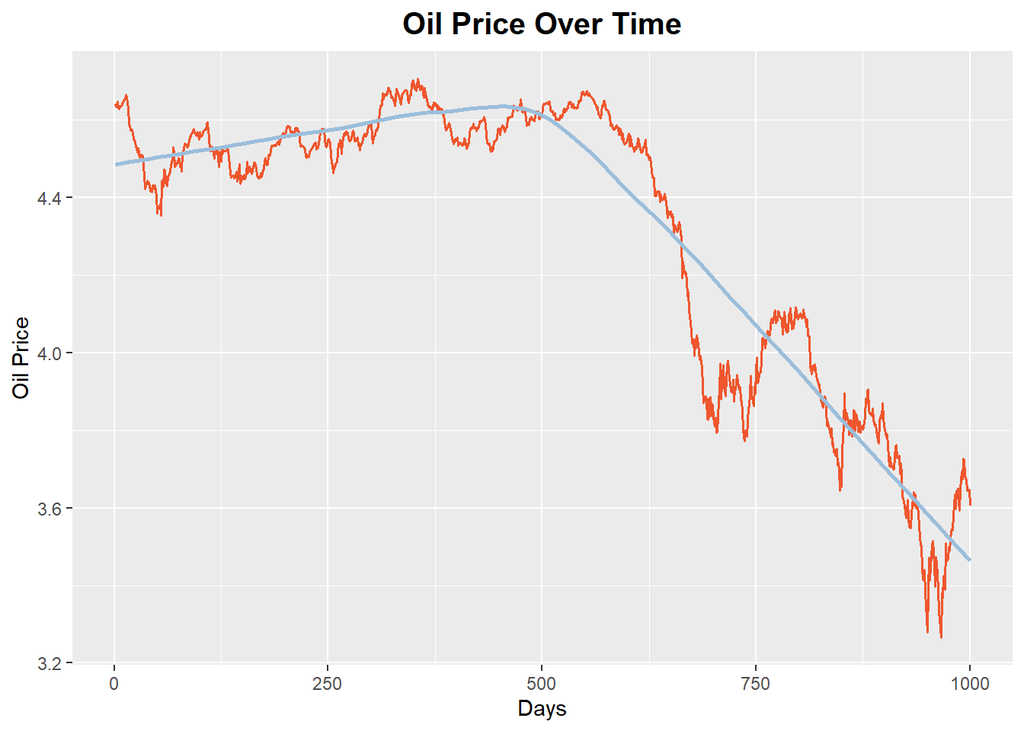

```r
# Create an index column
df$index <- 1:nrow(df)

# Plot Oil Price over Time with Trend Line
ggplot(df) +
  aes(x = index, y = OILPRICE) +
  geom_line(size = 0.7, colour = "#EF562D") +
  geom_smooth(method = "loess", colour = "#9BBEDB", se = FALSE) +
  labs(title = 'Oil Price Over Time', x = 'Days', y = 'Oil Price') +
  theme(plot.title = element_text(size = 15L, face = "bold", hjust = 0.5))
```

**We can observe that the response variable trends negatively over the given time period (here number of days).**

#### Exploring the variable distribution

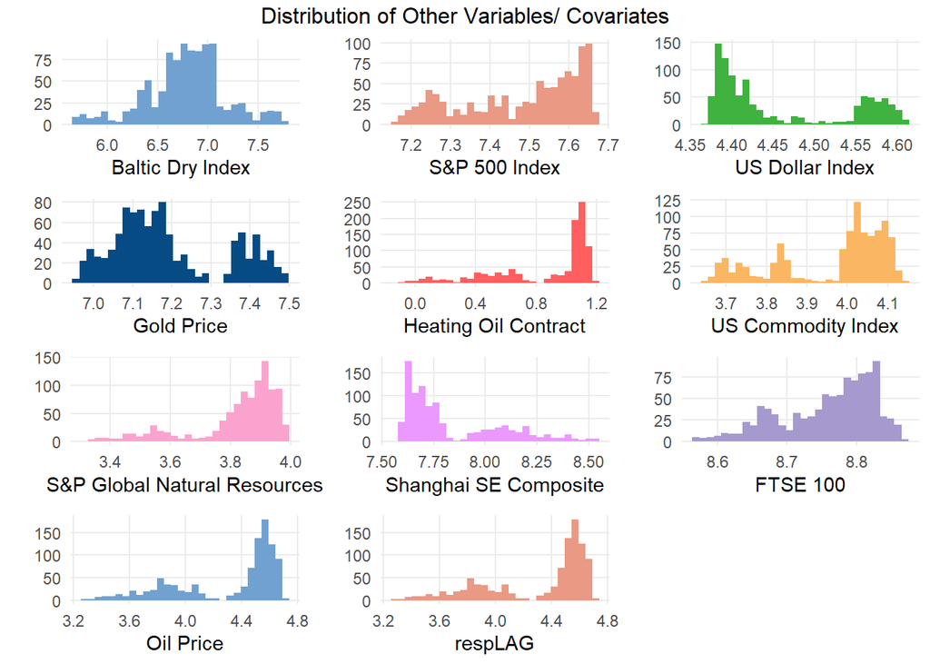

```r
# Create individual histograms
p1 <- ggplot(df) +
  aes(x = BDIY_log) +
  geom_histogram(bins = 30L, fill = "#71A1D0") +
  labs(x = "Baltic Dry Index", y = '') +
  theme_minimal() +
  theme(panel.grid.minor = element_blank())

p2 <- ggplot(df) +
  aes(x = SPX_log) +
  geom_histogram(bins = 30L, fill = "#E99984") +
  labs(x = "S&P 500 Index", y = '') +
  theme_minimal() +
  theme(panel.grid.minor = element_blank())

p3 <- ggplot(df) +
  aes(x = DX1_log) +
  geom_histogram(bins = 30L, fill = "#3FB23F") +
  labs(x = "US Dollar Index", y = '') +
  theme_minimal() +
  theme(panel.grid.minor = element_blank())

p4 <- ggplot(df) +
  aes(x = GC1_log) +
  geom_histogram(bins = 30L, fill = "#064B84") +
  labs(x = "Gold Price", y = '') +
  theme_minimal() +
  theme(panel.grid.minor = element_blank())

p5 <- ggplot(df) +
  aes(x = HO1_log) +
  geom_histogram(bins = 30L, fill = "#FF5F5F") +
  labs(x = "Heating Oil Contract", y = '') +
  theme_minimal() +
  theme(panel.grid.minor = element_blank())

p6 <- ggplot(df) +
  aes(x = USCI_log) +
  geom_histogram(bins = 30L, fill = "#FBB663") +
  labs(x = "US Commodity Index", y = '') +
  theme_minimal() +
  theme(panel.grid.minor = element_blank())

p7 <- ggplot(df) +
  aes(x = GNR_log) +
  geom_histogram(bins = 30L, fill = "#FBA3CF") +
  labs(x = "S&P Global Natural Resources", y = '') +
  theme_minimal() +
  theme(panel.grid.minor = element_blank())

p8 <- ggplot(df) +
  aes(x = SHCOMP_log) +
  geom_histogram(bins = 30L, fill = "#EB99FF") +
  labs(x = "Shanghai SE Composite", y = '') +
  theme_minimal() +
  theme(panel.grid.minor = element_blank())

p9 <- ggplot(df) +
  aes(x = FTSE_log) +
  geom_histogram(bins = 30L, fill = "#A699CD") +
  labs(x = "FTSE 100", y = '') +
  theme_minimal() +
  theme(panel.grid.minor = element_blank())

p10 <- ggplot(df) +
  aes(x = OILPRICE) +
  geom_histogram(bins = 30L, fill = "#71A1D0") +
  labs(x = "Oil Price", y = '') +
  theme_minimal() +
  theme(panel.grid.minor = element_blank())

p11 <- ggplot(df) +
  aes(x = respLAG) +
  geom_histogram(bins = 30L, fill = "#E99984") +
  labs(x = "respLAG", y = '') +
  theme_minimal() +
  theme(panel.grid.minor = element_blank())

# Arrange the plots using gridExtra
library(gridExtra)
grid.arrange(
  p1, p2, p3, p4, p5, p6, p7, p8, p9, p10, p11,
  ncol = 3,
  top = "Distribution of Other Variables/ Covariates"
)
```

**We see no clear indication of a normal distribution in these variables other than maybe the Baltic dry index.**

## Normality Test

- In this analysis, normality test is conducted to evaluate the distribution of variables influencing oil prices. The objective is to determine whether parametric models, which assume normally distributed residuals, are appropriate for modeling these relationships. If the normality assumption is violated, it may impact the accuracy of hypothesis testing and confidence intervals, leading to unreliable conclusions.
- Despite initial observations showing that most variables do not exhibit a clear normal distribution (except possibly the Baltic Dry Index), conducting formal normality tests is crucial. This test will provide statistical evidence to confirm or refute the visual assessments.

```r
# List of variables to test for normality
vars <- c("BDIY_log", "SPX_log", "DX1_log", "GC1_log", "HO1_log",
          "USCI_log", "GNR_log", "SHCOMP_log", "FTSE_log",
          "OILPRICE", "respLAG")

# Perform Shapiro-Wilk test
normality_results <- sapply(vars, function(var) {
  shapiro.test(oil[[var]])$p.value
})

# Print the results
normality_results
```

```
##     BDIY_log      SPX_log      DX1_log      GC1_log      HO1_log     USCI_log
## 4.261422e-11 9.774797e-26 2.611063e-33 4.847401e-23 8.579940e-34 1.613913e-29
##      GNR_log   SHCOMP_log     FTSE_log     OILPRICE      respLAG
## 2.787635e-32 1.454038e-30 1.027053e-20 3.736532e-32 3.468489e-32
```

**The p-values obtained from the normality tests for the variables are all extremely low (p < 0.05), indicating a significant deviation from normality. This confirms the initial observation that most variables do not follow a normal distribution, except for the Baltic Dry Index, which was visually closer to normality but still failed the test.**

## Stationarity Test

- We are conducting stationarity tests to ensure reliable modeling and avoid spurious correlations in our analysis of oil prices and financial indices. Time series models require stationary data for accurate forecasting, and identifying non-stationary series will help us apply appropriate transformations for robust analysis.

We will perform the stationarity test using the Augmented Dickey-Fuller (ADF) test:

```r
# Perform ADF test for each variable
adf_results <- lapply(df, adf.test)

# Display the results
adf_results
```

```
## $OILPRICE
##
##  Augmented Dickey-Fuller Test
##
## data:  X[[i]]
## Dickey-Fuller = -1.4688, Lag order = 9, p-value = 0.8031
## alternative hypothesis: stationary
##
##
## $BDIY_log
##
##  Augmented Dickey-Fuller Test
##
## data:  X[[i]]
## Dickey-Fuller = -2.7418, Lag order = 9, p-value = 0.2643
## alternative hypothesis: stationary
##
##
## $SPX_log
##
##  Augmented Dickey-Fuller Test
##
## data:  X[[i]]
## Dickey-Fuller = -1.6016, Lag order = 9, p-value = 0.7469
## alternative hypothesis: stationary
##
##
## $DX1_log
##
##  Augmented Dickey-Fuller Test
##
## data:  X[[i]]
## Dickey-Fuller = -1.7396, Lag order = 9, p-value = 0.6885
## alternative hypothesis: stationary
##
##
## $GC1_log
##
##  Augmented Dickey-Fuller Test
##
```

[output cut: 51 more lines]

```
##
##  Augmented Dickey-Fuller Test
##
## data:  X[[i]]
## Dickey-Fuller = -1.5112, Lag order = 9, p-value = 0.7852
## alternative hypothesis: stationary
##
##
## $index
##
##  Augmented Dickey-Fuller Test
##
## data:  X[[i]]
## Dickey-Fuller = -1.7321, Lag order = 9, p-value = 0.6917
## alternative hypothesis: stationary
```

- The variables in the dataset are already transformed with the Log transformations, applying more changes to these variables, would bring a complex interpretation of the dataset and a very generic prediction. The model accepts many distributions for the independent variables, it means that We will not transform our variables distributions. Prices have frequently asymmetric distributions, and they are well fitted in the GAMLSS.

## Variables Correlation

- As we have seen, the **variables don’t follow a normal distribution**, so if we want to analyse a correlation metric, it will need a **non parametric** Correlation-test (Spearmen).

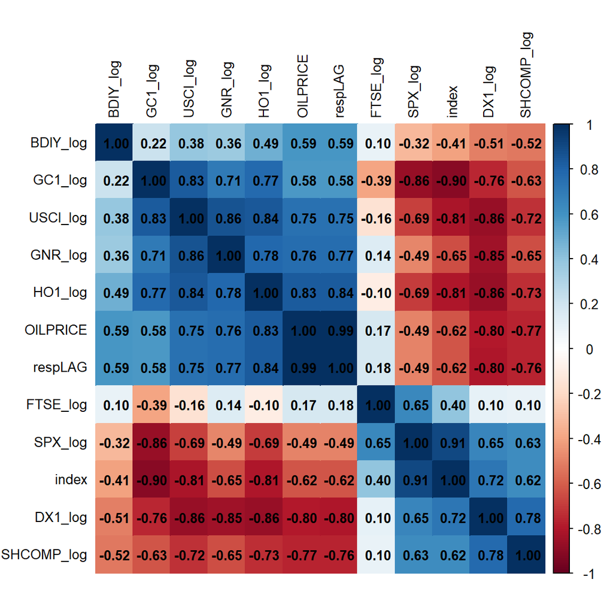

We now have to check how significant these correlations are :

```r
matrix <- rcorr(as.matrix(df), type = "spearman")
print(matrix$P)# P-value of the correlations
```

```
##                OILPRICE     BDIY_log SPX_log     DX1_log      GC1_log
## OILPRICE             NA 0.000000e+00       0 0.000000000 0.000000e+00
## BDIY_log   0.000000e+00           NA       0 0.000000000 3.120171e-12
## SPX_log    0.000000e+00 0.000000e+00      NA 0.000000000 0.000000e+00
## DX1_log    0.000000e+00 0.000000e+00       0          NA 0.000000e+00
## GC1_log    0.000000e+00 3.120171e-12       0 0.000000000           NA
## HO1_log    0.000000e+00 0.000000e+00       0 0.000000000 0.000000e+00
## USCI_log   0.000000e+00 0.000000e+00       0 0.000000000 0.000000e+00
## GNR_log    0.000000e+00 0.000000e+00       0 0.000000000 0.000000e+00
## SHCOMP_log 0.000000e+00 0.000000e+00       0 0.000000000 0.000000e+00
## FTSE_log   3.288032e-08 2.359658e-03       0 0.001514743 0.000000e+00
## respLAG    0.000000e+00 0.000000e+00       0 0.000000000 0.000000e+00
## index      0.000000e+00 0.000000e+00       0 0.000000000 0.000000e+00
##                HO1_log     USCI_log      GNR_log  SHCOMP_log     FTSE_log
## OILPRICE   0.000000000 0.000000e+00 0.000000e+00 0.000000000 3.288032e-08
## BDIY_log   0.000000000 0.000000e+00 0.000000e+00 0.000000000 2.359658e-03
## SPX_log    0.000000000 0.000000e+00 0.000000e+00 0.000000000 0.000000e+00
## DX1_log    0.000000000 0.000000e+00 0.000000e+00 0.000000000 1.514743e-03
## GC1_log    0.000000000 0.000000e+00 0.000000e+00 0.000000000 0.000000e+00
## HO1_log             NA 0.000000e+00 0.000000e+00 0.000000000 2.122789e-03
## USCI_log   0.000000000           NA 0.000000e+00 0.000000000 4.528966e-07
## GNR_log    0.000000000 0.000000e+00           NA 0.000000000 7.927264e-06
## SHCOMP_log 0.000000000 0.000000e+00 0.000000e+00          NA 2.344613e-03
## FTSE_log   0.002122789 4.528966e-07 7.927264e-06 0.002344613           NA
## respLAG    0.000000000 0.000000e+00 0.000000e+00 0.000000000 2.247735e-08
## index      0.000000000 0.000000e+00 0.000000e+00 0.000000000 0.000000e+00
##                 respLAG index
## OILPRICE   0.000000e+00     0
## BDIY_log   0.000000e+00     0
## SPX_log    0.000000e+00     0
## DX1_log    0.000000e+00     0
## GC1_log    0.000000e+00     0
## HO1_log    0.000000e+00     0
## USCI_log   0.000000e+00     0
## GNR_log    0.000000e+00     0
## SHCOMP_log 0.000000e+00     0
## FTSE_log   2.247735e-08     0
## respLAG              NA     0
## index      0.000000e+00    NA
```

## Distribution Selection

- It is essential to explore all available distributions within the package to identify the one with the lowest non-parametric test values. We will evaluate different distributions, starting from the simplest and progressing to more complex ones, while comparing their statistical metrics to determine the best fit.

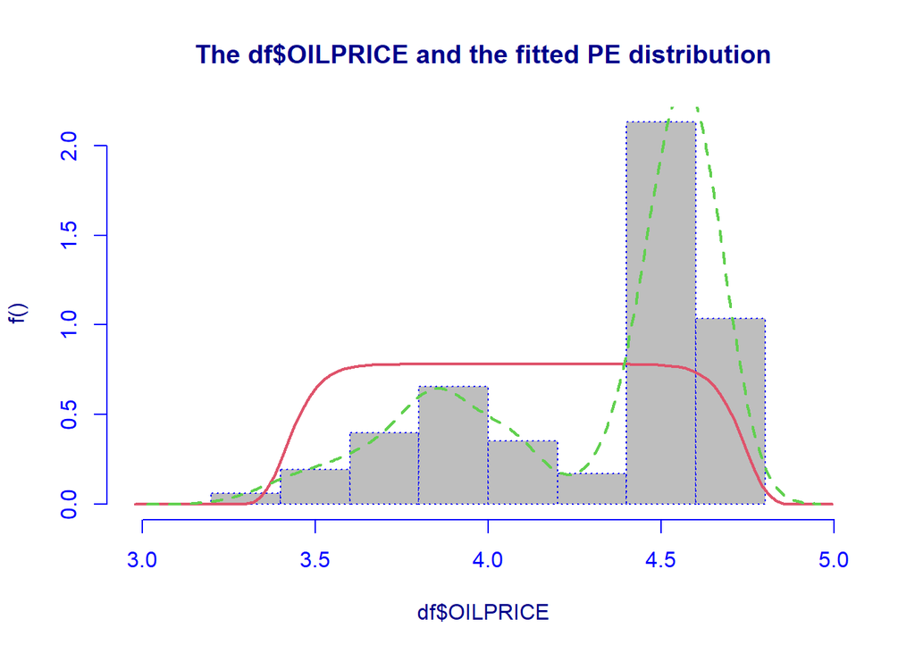

```
##
## Family:  c("PE", "Power Exponential")
## Fitting method: "nlminb"
##
## Call:  gamlssML(formula = df$OILPRICE, family = "PE")
##
## Mu Coefficients:
## [1]  4.079
## Sigma Coefficients:
## [1]  -0.9781
## Nu Coefficients:
## [1]  2.433
##
##  Degrees of Freedom for the fit: 3 Residual Deg. of Freedom   997
## Global Deviance:     671.657
##             AIC:     677.657
##             SBC:     692.38
```

```r
# Power Exponential distribution
histDist(df$OILPRICE, family=PE, density=TRUE)
```

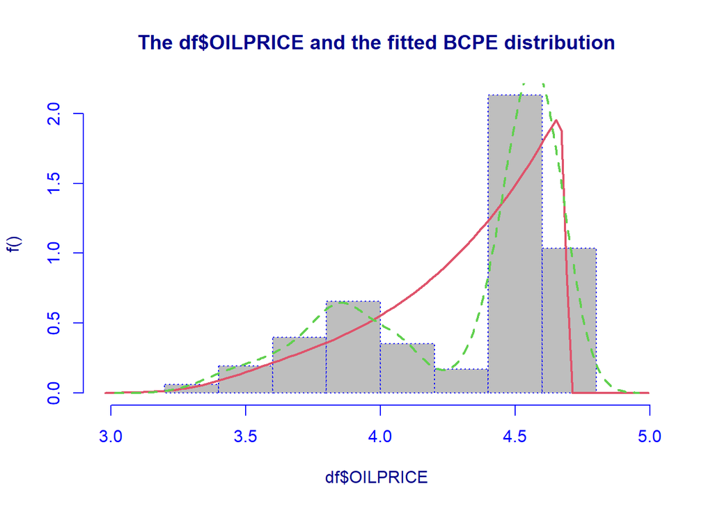

```
##
## Family:  c("BCPE", "Box-Cox Power Exponential")
## Fitting method: "nlminb"
##
## Call:  gamlssML(formula = df$OILPRICE, family = "BCPE")
##
## Mu Coefficients:
## [1]  4.374
## Sigma Coefficients:
## [1]  -2.877
## Nu Coefficients:
## [1]  9.382
## Tau Coefficients:
## [1]  3.339
##
##  Degrees of Freedom for the fit: 4 Residual Deg. of Freedom   996
## Global Deviance:     65.6076
##             AIC:     73.6076
##             SBC:     93.2387
```

```r
# BCPE distribution
histDist(df$OILPRICE, family = BCPE, density = TRUE)
```

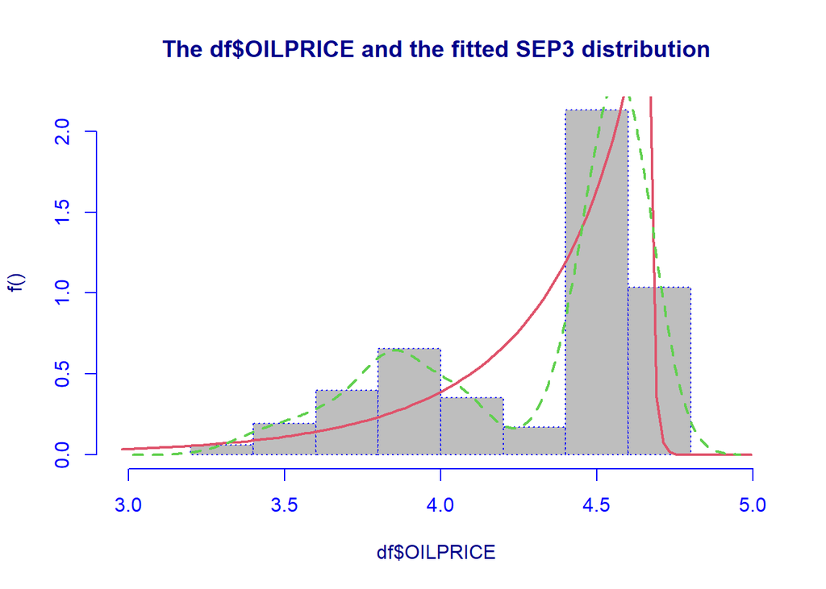

```
##
## Family:  c("SEP3", "skew exponential power type 3")
## Fitting method: "nlminb"
##
## Call:  gamlssML(formula = df$OILPRICE, family = "SEP3")
##
## Mu Coefficients:
## [1]  4.668
## Sigma Coefficients:
## [1]  -3.877
## Nu Coefficients:
## [1]  -1.721
## Tau Coefficients:
## [1]  -0.1942
##
##  Degrees of Freedom for the fit: 4 Residual Deg. of Freedom   996
## Global Deviance:     69.5331
##             AIC:     77.5331
##             SBC:     97.1641
```

```r
# SEP3 distribution
histDist(df$OILPRICE, family = SEP3, density = TRUE)
```

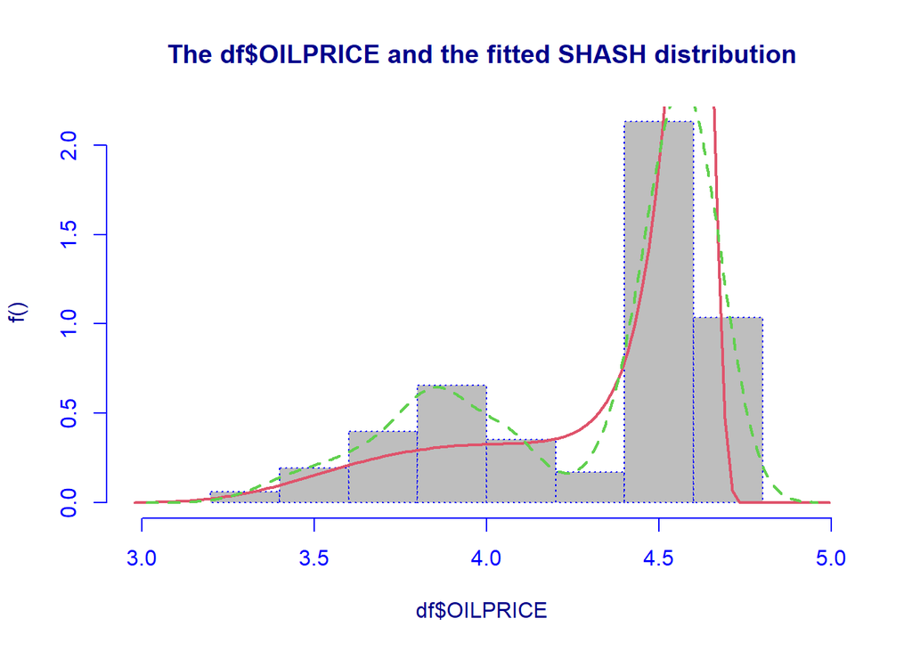

```
##
## Family:  c("SHASH", "Sinh-Arcsinh")
## Fitting method: "nlminb"
##
## Call:  gamlssML(formula = df$OILPRICE, family = "SHASH")
##
## Mu Coefficients:
## [1]  4.524
## Sigma Coefficients:
## [1]  9.999
## Nu Coefficients:
## [1]  10.28
## Tau Coefficients:
## [1]  12.37
##
##  Degrees of Freedom for the fit: 4 Residual Deg. of Freedom   996
## Global Deviance:     -232.604
##             AIC:     -224.604
##             SBC:     -204.973
```

```r
# SHASH distribution
histDist(df$OILPRICE,family = SHASH ,density = TRUE)
```

**Comparing the 4 distributions, the last instance of SHASH is the best option because it has the lowest values for Global Deviance, AIC, and SBC (even negative, which indicates a very good fit). Negative AIC and SBC are rare and suggest an excellent fit.**

## Data Preparation

```r
# Remove the FTSE_log column from the dataframe to exclude the variable with low correlation to OILPRICE
df_1 <- subset(df, select = -FTSE_log)

# Remove the respLAG column to create a dataset with only external predictors (e.g., stock indices)
df_2 <- subset(df_1, select = -respLAG)
```

- Splitting train and test data. **80 - 20 split**.

```r
set.seed(123)

sample_size_1 <- floor(0.8 * nrow(df_1))

train_1 <- sample(seq_len(nrow(df_1)), size = sample_size_1)

# Split df_1 into training and testing sets
train_data_1 <- df_1[train_1, ]
test_data_1 <- df_1[-train_1, ]


sample_size_2 <- floor(0.8 * nrow(df_2))

train_2 <- sample(seq_len(nrow(df_2)), size = sample_size_2)

# Split df_2 into training and testing sets
train_data_2 <- df_2[train_2, ]
test_data_2 <- df_2[-train_2, ]
```

## Model Building

- Building the first model using the dataset df_1, which includes the lagged variable respLAG and excludes the low-correlation variable FTSE_log. The model is built using the SHASH distribution.

```r
model_1 <- gamlss(OILPRICE ~ ., family = SHASH, data = train_data_1)
```

```
## GAMLSS-RS iteration 1: Global Deviance = -4047.631
## GAMLSS-RS iteration 2: Global Deviance = -4055.472
## GAMLSS-RS iteration 3: Global Deviance = -4056.241
## GAMLSS-RS iteration 4: Global Deviance = -4056.723
## GAMLSS-RS iteration 5: Global Deviance = -4057.048
## GAMLSS-RS iteration 6: Global Deviance = -4057.268
## GAMLSS-RS iteration 7: Global Deviance = -4057.415
## GAMLSS-RS iteration 8: Global Deviance = -4057.516
## GAMLSS-RS iteration 9: Global Deviance = -4057.584
## GAMLSS-RS iteration 10: Global Deviance = -4057.63
## GAMLSS-RS iteration 11: Global Deviance = -4057.661
## GAMLSS-RS iteration 12: Global Deviance = -4057.682
## GAMLSS-RS iteration 13: Global Deviance = -4057.697
## GAMLSS-RS iteration 14: Global Deviance = -4057.707
## GAMLSS-RS iteration 15: Global Deviance = -4057.714
## GAMLSS-RS iteration 16: Global Deviance = -4057.719
## GAMLSS-RS iteration 17: Global Deviance = -4057.722
## GAMLSS-RS iteration 18: Global Deviance = -4057.724
## GAMLSS-RS iteration 19: Global Deviance = -4057.726
## GAMLSS-RS iteration 20: Global Deviance = -4057.727
```

- Building the second model using the dataset df_2, which excludes the lagged variable respLAG and the low-correlation variable FTSE_log. The model is also built using the SHASH distribution.

```r
model_2 <- gamlss(OILPRICE ~ ., family = SHASH, data = train_data_2)
```

```
## GAMLSS-RS iteration 1: Global Deviance = -2413.031
## GAMLSS-RS iteration 2: Global Deviance = -2443.918
## GAMLSS-RS iteration 3: Global Deviance = -2457.956
## GAMLSS-RS iteration 4: Global Deviance = -2468.708
## GAMLSS-RS iteration 5: Global Deviance = -2477.125
## GAMLSS-RS iteration 6: Global Deviance = -2483.981
## GAMLSS-RS iteration 7: Global Deviance = -2489.423
## GAMLSS-RS iteration 8: Global Deviance = -2493.733
## GAMLSS-RS iteration 9: Global Deviance = -2497.324
## GAMLSS-RS iteration 10: Global Deviance = -2500.214
## GAMLSS-RS iteration 11: Global Deviance = -2502.635
## GAMLSS-RS iteration 12: Global Deviance = -2504.665
## GAMLSS-RS iteration 13: Global Deviance = -2506.367
## GAMLSS-RS iteration 14: Global Deviance = -2507.767
## GAMLSS-RS iteration 15: Global Deviance = -2509.034
## GAMLSS-RS iteration 16: Global Deviance = -2510.077
## GAMLSS-RS iteration 17: Global Deviance = -2510.963
## GAMLSS-RS iteration 18: Global Deviance = -2511.71
## GAMLSS-RS iteration 19: Global Deviance = -2512.377
## GAMLSS-RS iteration 20: Global Deviance = -2512.932
```

## Comparing Model Performance

```r
# Display detailed summary for Model 1
cat("Summary of Model 1:\n")
```

```
## Summary of Model 1:
```

```r
summary(model_1)
```

```
## Family:  c("SHASH", "Sinh-Arcsinh")
##
## Call:  gamlss(formula = OILPRICE ~ ., family = SHASH, data = train_data_1)
##
## Fitting method: RS()
##
## ------------------------------------------------------------------
## Mu link function:  identity
## Mu Coefficients:
##               Estimate Std. Error t value Pr(>|t|)
## (Intercept)  1.089e+00  3.235e-01   3.366 0.000801 ***
## BDIY_log    -2.421e-03  2.460e-03  -0.984 0.325420
## SPX_log     -1.151e-01  3.228e-02  -3.564 0.000387 ***
## DX1_log      3.475e-02  3.570e-02   0.973 0.330685
## GC1_log     -6.279e-02  1.745e-02  -3.599 0.000339 ***
## HO1_log      4.158e-03  1.461e-02   0.285 0.776095
## USCI_log    -1.136e-02  2.213e-02  -0.514 0.607735
## GNR_log      7.919e-02  2.455e-02   3.225 0.001311 **
## SHCOMP_log  -1.668e-02  6.817e-03  -2.446 0.014653 *
## respLAG      9.851e-01  1.047e-02  94.069  < 2e-16 ***
## index        3.576e-05  1.662e-05   2.152 0.031724 *
## ---
## Signif. codes:  0 '***' 0.001 '**' 0.01 '*' 0.05 '.' 0.1 ' ' 1
##
## ------------------------------------------------------------------
## Sigma link function:  log
## Sigma Coefficients:
##             Estimate Std. Error t value Pr(>|t|)
## (Intercept)  -5.0088     0.0372  -134.6   <2e-16 ***
## ---
## Signif. codes:  0 '***' 0.001 '**' 0.01 '*' 0.05 '.' 0.1 ' ' 1
##
## ------------------------------------------------------------------
## Nu link function:  log
## Nu Coefficients:
##             Estimate Std. Error t value Pr(>|t|)
## (Intercept)  -0.5944     0.0253  -23.49   <2e-16 ***
## ---
## Signif. codes:  0 '***' 0.001 '**' 0.01 '*' 0.05 '.' 0.1 ' ' 1
##
## ------------------------------------------------------------------
## Tau link function:  log
## Tau Coefficients:
##             Estimate Std. Error t value Pr(>|t|)
## (Intercept) -0.62218    0.02503  -24.85   <2e-16 ***
## ---
## Signif. codes:  0 '***' 0.001 '**' 0.01 '*' 0.05 '.' 0.1 ' ' 1
##
## ------------------------------------------------------------------
## No. of observations in the fit:  800
## Degrees of Freedom for the fit:  14
##       Residual Deg. of Freedom:  786
##                       at cycle:  20
##
## Global Deviance:     -4057.727
##             AIC:     -4029.727
##             SBC:     -3964.142
```

```r
# Display detailed summary for Model 2
cat("\nSummary of Model 2:\n")
```

```
##
## Summary of Model 2:
```

```r
summary(model_2)
```

```
## Family:  c("SHASH", "Sinh-Arcsinh")
##
## Call:  gamlss(formula = OILPRICE ~ ., family = SHASH, data = train_data_2)
##
## Fitting method: RS()
##
## ------------------------------------------------------------------
## Mu link function:  identity
## Mu Coefficients:
##               Estimate Std. Error  t value Pr(>|t|)
## (Intercept)  1.319e+01  4.415e-01   29.875  < 2e-16 ***
## BDIY_log    -6.314e-02  7.475e-03   -8.446  < 2e-16 ***
## SPX_log     -2.026e-02  1.972e-02   -1.028 0.304441
## DX1_log     -1.332e+00  9.995e-02  -13.329  < 2e-16 ***
## GC1_log     -5.129e-01  2.025e-02  -25.327  < 2e-16 ***
## HO1_log      9.960e-01  2.909e-02   34.235  < 2e-16 ***
## USCI_log     1.727e-01  6.249e-02    2.764 0.005838 **
## GNR_log     -1.890e-01  5.220e-02   -3.621 0.000312 ***
## SHCOMP_log   6.787e-02  2.006e-02    3.383 0.000753 ***
## index       -2.579e-05  1.229e-07 -209.906  < 2e-16 ***
## ---
## Signif. codes:  0 '***' 0.001 '**' 0.01 '*' 0.05 '.' 0.1 ' ' 1
##
## ------------------------------------------------------------------
## Sigma link function:  log
## Sigma Coefficients:
##             Estimate Std. Error t value Pr(>|t|)
## (Intercept) -3.29330    0.06837  -48.17   <2e-16 ***
## ---
## Signif. codes:  0 '***' 0.001 '**' 0.01 '*' 0.05 '.' 0.1 ' ' 1
##
## ------------------------------------------------------------------
## Nu link function:  log
## Nu Coefficients:
##             Estimate Std. Error t value Pr(>|t|)
## (Intercept) -0.35532    0.04927  -7.212 1.29e-12 ***
## ---
## Signif. codes:  0 '***' 0.001 '**' 0.01 '*' 0.05 '.' 0.1 ' ' 1
##
## ------------------------------------------------------------------
## Tau link function:  log
## Tau Coefficients:
##             Estimate Std. Error t value Pr(>|t|)
## (Intercept) -0.01057    0.02021  -0.523    0.601
##
## ------------------------------------------------------------------
## No. of observations in the fit:  800
## Degrees of Freedom for the fit:  13
##       Residual Deg. of Freedom:  787
##                       at cycle:  20
##
## Global Deviance:     -2512.932
##             AIC:     -2486.932
##             SBC:     -2426.032
```

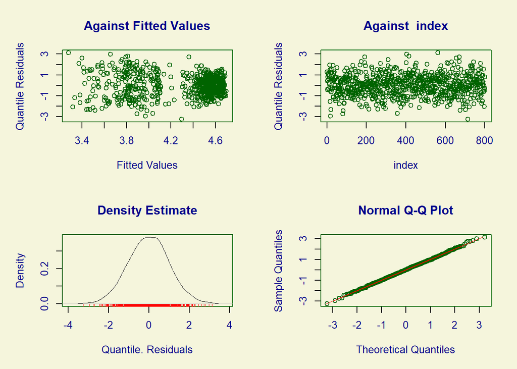

```
##        Summary of the Quantile Residuals
##                            mean   =  -0.007628046
##                        variance   =  0.9993922
##                coef. of skewness  =  0.01397907
##                coef. of kurtosis  =  3.011013
## Filliben correlation coefficient  =  0.9997652
```

```r
# Residual Analysis

plot(model_1)
```

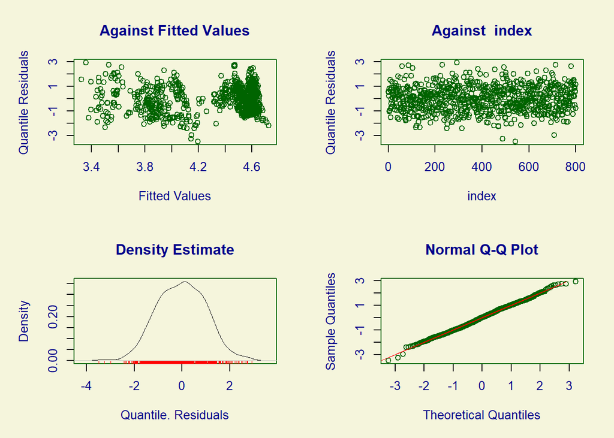

```
##        Summary of the Quantile Residuals
##                            mean   =  -0.01633284
##                        variance   =  1.023084
##                coef. of skewness  =  0.005557451
##                coef. of kurtosis  =  2.85151
## Filliben correlation coefficient  =  0.9988508
```

```r
plot(model_2)
```

#### Comparison of Model Performance:

Conclusion:

- **Model 1 performs better than Model 2 on almost all criteria** (Global Deviance, AIC, SBC, kurtosis, and Filliben Correlation). Therefore, Model 1 is the better model.
- Model 1 likely performs better because it uses respLAG, which includes information about the previous day’s OILPRICE. This helps the model understand how oil prices change over time.
- In financial data, today’s prices are often influenced by yesterday’s prices. By using respLAG, Model 1 captures these patterns better than Model 2, which doesn’t have this information.

#### Prediction Accuracy

Even after looking at the model summary and residuals, testing prediction accuracy is important because:  
- **Generalization:** It checks if the model works well on new, unseen data, not just the training set.  
- **Overfitting Detection:** A model might fit the training data perfectly but fail on new data. Testing accuracy helps spot this.  
- **Real-World Use:** The goal is to make accurate predictions on future data, so testing accuracy shows how reliable the model is.

In short, testing prediction accuracy ensures the model is good not just for training data but also for real-world use.

```r
# Make predictions on the test set
pred_model_1 <- predict(model_1, newdata = test_data_1, type = "response")
pred_model_2 <- predict(model_2, newdata = test_data_2, type = "response")

# Calculate accuracy metrics
mae_model_1 <- mean(abs(pred_model_1 - test_data_1$OILPRICE))
rmse_model_1 <- sqrt(mean((pred_model_1 - test_data_1$OILPRICE)^2))

mae_model_2 <- mean(abs(pred_model_2 - test_data_2$OILPRICE))
rmse_model_2 <- sqrt(mean((pred_model_2 - test_data_2$OILPRICE)^2))

# Print accuracy metrics
cat("Model 1 Accuracy:\n")
```

```
## Model 1 Accuracy:
```

```r
cat("MAE:", mae_model_1, "\n")
```

```
## MAE: 0.01641625
```

```r
cat("RMSE:", rmse_model_1, "\n\n")
```

```
## RMSE: 0.02469706
```

```r
cat("Model 2 Accuracy:\n")
```

```
## Model 2 Accuracy:
```

```r
cat("MAE:", mae_model_2, "\n")
```

```
## MAE: 0.04341889
```

```r
cat("RMSE:", rmse_model_2, "\n")
```

```
## RMSE: 0.05616412
```

- **Model 1 performs better than Model 2 based on both MAE and RMSE. This suggests that Model 1 is more accurate and reliable in predicting OILPRICE.**
- **Model 2 shows higher errors, suggesting that its predictions are less accurate and more dispersed from the actual values.**

## Building new models with additive term

- To fit non-linear, non-parametric relationships or account for random effects, an additive term function is needed. In this context, smooth functions help capture complex patterns in the data.
- After experimenting with various smoothing methods, cubic splines provided the best non-parametric fit. Cubic splines are powerful because they allow flexible modeling while maintaining smoothness.

```r
# Build Model 3 with cubic splines for selected variables. To see if there is any improvement in model 1 performance.
model_3 <- gamlss(
  OILPRICE ~ cs(BDIY_log, df = 5) + cs(SPX_log, df = 5) + cs(DX1_log, df = 5) +
    cs(GC1_log, df = 5) + cs(HO1_log, df = 5) + cs(USCI_log, df = 5) +
    cs(GNR_log, df = 5) + cs(SHCOMP_log, df = 5),
  family = SHASH,
  data = train_data_1
)
```

```
## GAMLSS-RS iteration 1: Global Deviance = -3500.622
## GAMLSS-RS iteration 2: Global Deviance = -3215.247
## GAMLSS-RS iteration 3: Global Deviance = -3219.822
## GAMLSS-RS iteration 4: Global Deviance = -3228.197
## GAMLSS-RS iteration 5: Global Deviance = -3235.372
## GAMLSS-RS iteration 6: Global Deviance = -3241.782
## GAMLSS-RS iteration 7: Global Deviance = -3249.02
## GAMLSS-RS iteration 8: Global Deviance = -3253.415
## GAMLSS-RS iteration 9: Global Deviance = -3257.494
## GAMLSS-RS iteration 10: Global Deviance = -3261.16
## GAMLSS-RS iteration 11: Global Deviance = -3264.126
## GAMLSS-RS iteration 12: Global Deviance = -3266.925
## GAMLSS-RS iteration 13: Global Deviance = -3269.061
## GAMLSS-RS iteration 14: Global Deviance = -3271.075
## GAMLSS-RS iteration 15: Global Deviance = -3272.876
## GAMLSS-RS iteration 16: Global Deviance = -3274.269
## GAMLSS-RS iteration 17: Global Deviance = -3275.539
## GAMLSS-RS iteration 18: Global Deviance = -3276.494
## GAMLSS-RS iteration 19: Global Deviance = -3277.464
## GAMLSS-RS iteration 20: Global Deviance = -3278.3
```

```r
# Build Model 3 with cubic splines for selected variables. To see if there is any improvement in model 2 performance.
model_4 <- gamlss(
  OILPRICE ~ cs(BDIY_log, df = 5) + cs(SPX_log, df = 5) + cs(DX1_log, df = 5) +
    cs(GC1_log, df = 5) + cs(HO1_log, df = 5) + cs(USCI_log, df = 5) +
    cs(GNR_log, df = 5) + cs(SHCOMP_log, df = 5),
  family = SHASH,
  data = train_data_2
)
```

```
## GAMLSS-RS iteration 1: Global Deviance = -3436.464
## GAMLSS-RS iteration 2: Global Deviance = -3179.319
## GAMLSS-RS iteration 3: Global Deviance = -3186.535
## GAMLSS-RS iteration 4: Global Deviance = -3195.457
## GAMLSS-RS iteration 5: Global Deviance = -3201.377
## GAMLSS-RS iteration 6: Global Deviance = -3206.062
## GAMLSS-RS iteration 7: Global Deviance = -3210.349
## GAMLSS-RS iteration 8: Global Deviance = -3214.494
## GAMLSS-RS iteration 9: Global Deviance = -3218.022
## GAMLSS-RS iteration 10: Global Deviance = -3221.112
## GAMLSS-RS iteration 11: Global Deviance = -3223.808
## GAMLSS-RS iteration 12: Global Deviance = -3226.174
## GAMLSS-RS iteration 13: Global Deviance = -3228.209
## GAMLSS-RS iteration 14: Global Deviance = -3230.085
## GAMLSS-RS iteration 15: Global Deviance = -3231.713
## GAMLSS-RS iteration 16: Global Deviance = -3233.052
## GAMLSS-RS iteration 17: Global Deviance = -3234.337
## GAMLSS-RS iteration 18: Global Deviance = -3235.395
## GAMLSS-RS iteration 19: Global Deviance = -3236.317
## GAMLSS-RS iteration 20: Global Deviance = -3237.133
```

```r
# Display model summary
summary(model_3)
```

```
## Family:  c("SHASH", "Sinh-Arcsinh")
##
## Call:  gamlss(formula = OILPRICE ~ cs(BDIY_log, df = 5) +
##     cs(SPX_log, df = 5) + cs(DX1_log, df = 5) + cs(GC1_log,
##     df = 5) + cs(HO1_log, df = 5) + cs(USCI_log, df = 5) +
##     cs(GNR_log, df = 5) + cs(SHCOMP_log, df = 5), family = SHASH,
##     data = train_data_1)
##
## Fitting method: RS()
##
## ------------------------------------------------------------------
## Mu link function:  identity
## Mu Coefficients:
##                         Estimate Std. Error t value Pr(>|t|)
## (Intercept)             6.112775   0.199333  30.666   <2e-16 ***
## cs(BDIY_log, df = 5)    0.064874   0.004391  14.773   <2e-16 ***
## cs(SPX_log, df = 5)     0.001503   0.011921   0.126    0.900
## cs(DX1_log, df = 5)    -0.641148   0.073452  -8.729   <2e-16 ***
## cs(GC1_log, df = 5)    -0.238562   0.011640 -20.495   <2e-16 ***
## cs(HO1_log, df = 5)     0.783496   0.018075  43.347   <2e-16 ***
## cs(USCI_log, df = 5)    0.717795   0.041727  17.202   <2e-16 ***
## cs(GNR_log, df = 5)    -0.277842   0.028627  -9.705   <2e-16 ***
## cs(SHCOMP_log, df = 5) -0.016503   0.014065  -1.173    0.241
## ---
## Signif. codes:  0 '***' 0.001 '**' 0.01 '*' 0.05 '.' 0.1 ' ' 1
##
## ------------------------------------------------------------------
## Sigma link function:  log
## Sigma Coefficients:
##             Estimate Std. Error t value Pr(>|t|)
## (Intercept) -3.96786    0.09583   -41.4   <2e-16 ***
## ---
## Signif. codes:  0 '***' 0.001 '**' 0.01 '*' 0.05 '.' 0.1 ' ' 1
##
## ------------------------------------------------------------------
## Nu link function:  log
## Nu Coefficients:
##             Estimate Std. Error t value Pr(>|t|)
## (Intercept) -0.42677    0.05126  -8.325    4e-16 ***
## ---
```

[output cut: 8 more lines]

```
## Signif. codes:  0 '***' 0.001 '**' 0.01 '*' 0.05 '.' 0.1 ' ' 1
##
## ------------------------------------------------------------------
## NOTE: Additive smoothing terms exist in the formulas:
##  i) Std. Error for smoothers are for the linear effect only.
## ii) Std. Error for the linear terms maybe are not accurate.
## ------------------------------------------------------------------
## No. of observations in the fit:  800
## Degrees of Freedom for the fit:  52.00426
##       Residual Deg. of Freedom:  747.9957
##                       at cycle:  20
##
## Global Deviance:     -3278.3
##             AIC:     -3174.291
##             SBC:     -2930.672
```

```r
summary(model_4)
```

```
## Family:  c("SHASH", "Sinh-Arcsinh")
##
## Call:  gamlss(formula = OILPRICE ~ cs(BDIY_log, df = 5) +
##     cs(SPX_log, df = 5) + cs(DX1_log, df = 5) + cs(GC1_log,
##     df = 5) + cs(HO1_log, df = 5) + cs(USCI_log, df = 5) +
##     cs(GNR_log, df = 5) + cs(SHCOMP_log, df = 5), family = SHASH,
##     data = train_data_2)
##
## Fitting method: RS()
##
## ------------------------------------------------------------------
## Mu link function:  identity
## Mu Coefficients:
##                         Estimate Std. Error t value Pr(>|t|)
## (Intercept)             5.498215   0.363279  15.135  < 2e-16 ***
## cs(BDIY_log, df = 5)    0.078637   0.004832  16.274  < 2e-16 ***
## cs(SPX_log, df = 5)     0.010901   0.012435   0.877    0.381
## cs(DX1_log, df = 5)    -0.584929   0.095717  -6.111 1.59e-09 ***
## cs(GC1_log, df = 5)    -0.184725   0.010979 -16.825  < 2e-16 ***
## cs(HO1_log, df = 5)     0.780235   0.020439  38.174  < 2e-16 ***
## cs(USCI_log, df = 5)    0.662528   0.043992  15.060  < 2e-16 ***
## cs(GNR_log, df = 5)    -0.275131   0.036589  -7.520 1.58e-13 ***
## cs(SHCOMP_log, df = 5) -0.013827   0.017942  -0.771    0.441
## ---
## Signif. codes:  0 '***' 0.001 '**' 0.01 '*' 0.05 '.' 0.1 ' ' 1
##
## ------------------------------------------------------------------
## Sigma link function:  log
## Sigma Coefficients:
##             Estimate Std. Error t value Pr(>|t|)
## (Intercept) -3.96668    0.08424  -47.09   <2e-16 ***
## ---
## Signif. codes:  0 '***' 0.001 '**' 0.01 '*' 0.05 '.' 0.1 ' ' 1
##
## ------------------------------------------------------------------
## Nu link function:  log
## Nu Coefficients:
##             Estimate Std. Error t value Pr(>|t|)
## (Intercept) -0.42848    0.04931  -8.689   <2e-16 ***
## ---
```

[output cut: 8 more lines]

```
## Signif. codes:  0 '***' 0.001 '**' 0.01 '*' 0.05 '.' 0.1 ' ' 1
##
## ------------------------------------------------------------------
## NOTE: Additive smoothing terms exist in the formulas:
##  i) Std. Error for smoothers are for the linear effect only.
## ii) Std. Error for the linear terms maybe are not accurate.
## ------------------------------------------------------------------
## No. of observations in the fit:  800
## Degrees of Freedom for the fit:  52.00046
##       Residual Deg. of Freedom:  747.9995
##                       at cycle:  20
##
## Global Deviance:     -3237.133
##             AIC:     -3133.132
##             SBC:     -2889.53
```

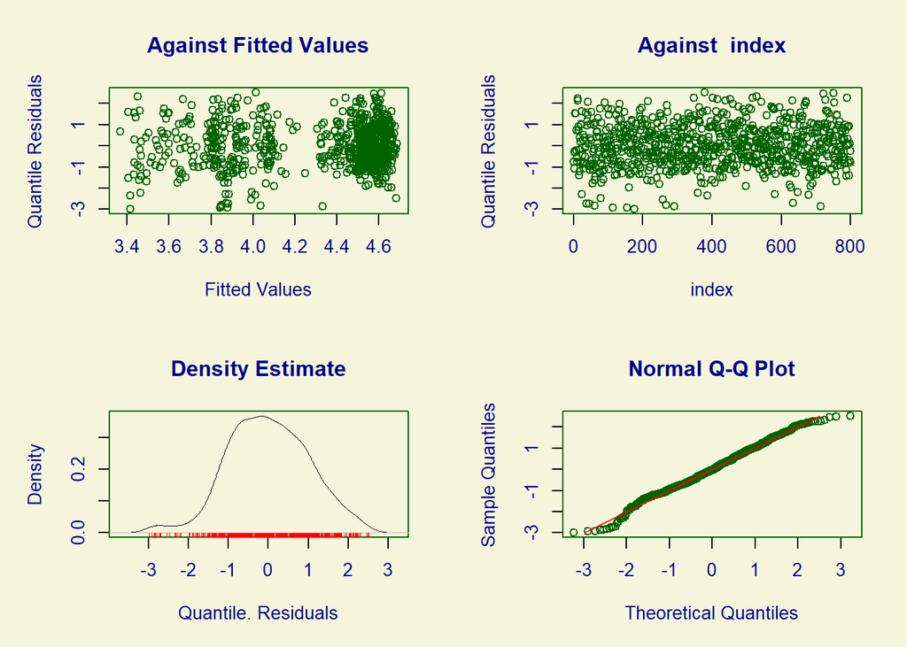

```
##        Summary of the Quantile Residuals
##                            mean   =  0.008407861
##                        variance   =  1.00677
##                coef. of skewness  =  -0.05960205
##                coef. of kurtosis  =  2.945354
## Filliben correlation coefficient  =  0.997179
```

```r
plot(model_3)
```

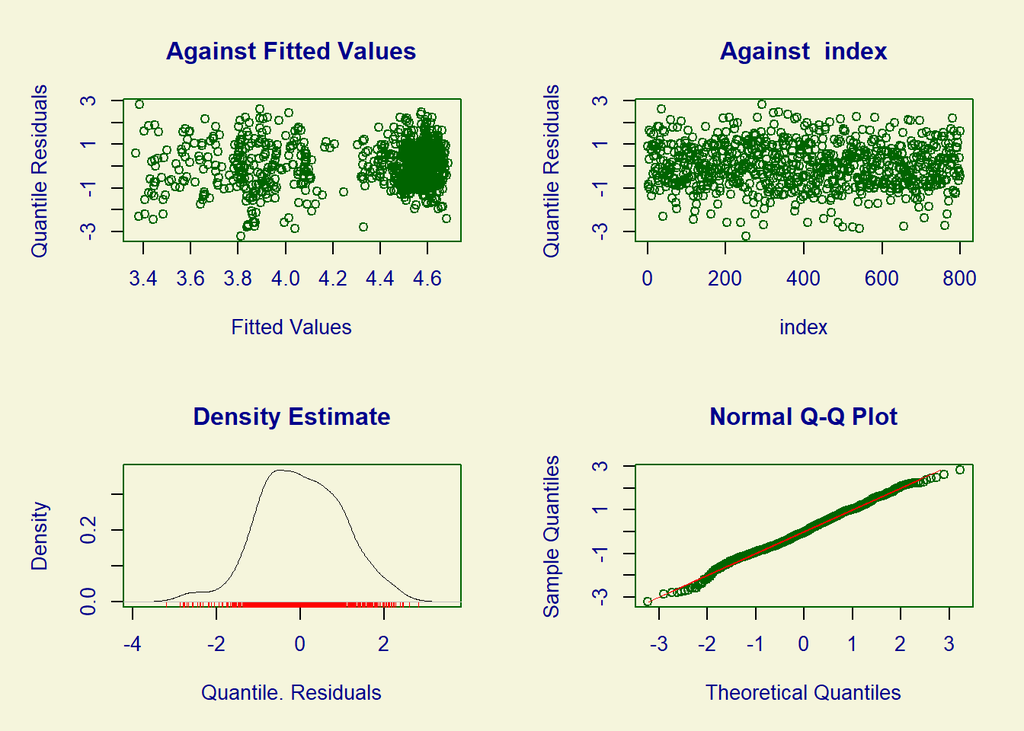

```
##        Summary of the Quantile Residuals
##                            mean   =  0.009342818
##                        variance   =  1.00594
##                coef. of skewness  =  -0.05545976
##                coef. of kurtosis  =  2.963007
## Filliben correlation coefficient  =  0.9978685
```

```r
plot(model_4)
```

```r
# Make predictions on the test set
pred_model_3 <- predict(model_3, newdata = test_data_1, type = "response")
pred_model_4 <- predict(model_4, newdata = test_data_2, type = "response")

mae_model_3 <- mean(abs(pred_model_3 - test_data_1$OILPRICE))
rmse_model_3 <- sqrt(mean((pred_model_3 - test_data_1$OILPRICE)^2))
mae_model_4 <- mean(abs(pred_model_4 - test_data_2$OILPRICE))
rmse_model_4 <- sqrt(mean((pred_model_4 - test_data_2$OILPRICE)^2))


cat("Model 3 Accuracy:\n")
```

```
## Model 3 Accuracy:
```

```r
cat("MAE:", mae_model_3, "\n")
```

```
## MAE: 0.02800448
```

```r
cat("RMSE:", rmse_model_3, "\n\n")
```

```
## RMSE: 0.03897589
```

```r
cat("Model 4 Accuracy:\n")
```

```
## Model 4 Accuracy:
```

```r
cat("MAE:", mae_model_4, "\n")
```

```
## MAE: 0.02537122
```

```r
cat("RMSE:", rmse_model_4, "\n\n")
```

```
## RMSE: 0.03466895
```

```r
# Combine the MAE and RMSE for all four models
mae_values <- c(mae_model_1, mae_model_2, mae_model_3, mae_model_4)
rmse_values <- c(rmse_model_1, rmse_model_2, rmse_model_3, rmse_model_4)
model_names <- c("Model 1", "Model 2", "Model 3", "Model 4")

comparison_df <- data.frame(
  Model = model_names,
  MAE = mae_values,
  RMSE = rmse_values
)

# Display the comparison table
print(comparison_df)
```

```
##     Model        MAE       RMSE
## 1 Model 1 0.01641625 0.02469706
## 2 Model 2 0.04341889 0.05616412
## 3 Model 3 0.02800448 0.03897589
## 4 Model 4 0.02537122 0.03466895
```

## Probabilistic Forecast

- Selecting **Model 1** as the best model to provide one day ahead probabilistic forecast for the oil prices :

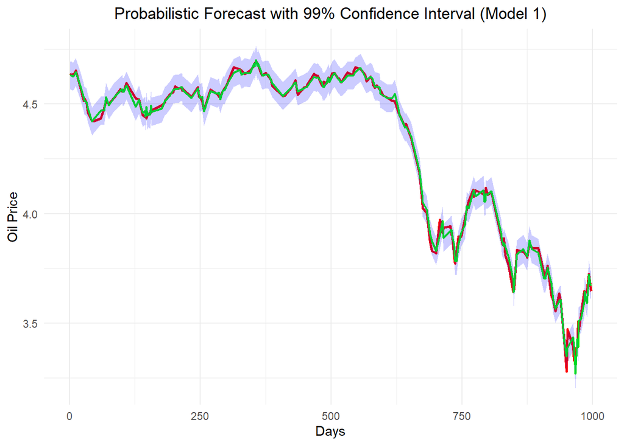

```r
# Calculate residuals and standard deviation of residuals
residuals_model_1 <- test_data_1$OILPRICE - pred_model_1
residual_sd <- sd(residuals_model_1)

# critical value for 99% confidence interval
critval <- 2.575

upper_band <- pred_model_1 + (critval * residual_sd)
lower_band <- pred_model_1 - (critval * residual_sd)

plot_data <- data.frame(
  Date = test_data_1$index,
  Actual = test_data_1$OILPRICE,
  Predicted = pred_model_1,
  Upper = upper_band,
  Lower = lower_band
)

# Create the plot
ggplot(plot_data, aes(x = Date)) +
  geom_line(aes(y = Actual), color = "red", size = 1, linetype = "solid") +  # Actual values
  geom_line(aes(y = Predicted), color = "green", size = 0.8) +  # Predicted values
  geom_ribbon(aes(ymin = Lower, ymax = Upper), fill = "blue", alpha = 0.2) +  # Confidence interval
  labs(
    title = "Probabilistic Forecast with 99% Confidence Interval (Model 1)",
    x = "Days",
    y = "Oil Price"
  ) +
  theme_minimal() +
  theme(
    plot.title = element_text(hjust = 0.5),
    legend.position = "none"
  )
```

**The blue shaded area shows the 99% confidence interval, indicating the range within which the actual oil price is expected to lie, 99% of the time. We can infer that actual values (red line) consistently fall within the confidence band, it suggests that the model’s predictions are reliable.**

```r
last_row <- tail(test_data_1, 1)

next_day_pred <- predict(model_1, newdata = last_row, type = "response")

# Display the prediction
cat("Predicted Oil Price for the Next Day:", next_day_pred, "\n")
```

```
## Predicted Oil Price for the Next Day: 3.670537
```

```r
next_day_actual <- tail(test_data_1$OILPRICE, 1)

percent_deviation <- ((next_day_pred - next_day_actual) / next_day_actual) * 100

# Display the percent deviation
cat("Percent Deviation from True Value for the Next Day:", round(percent_deviation, 2), "%\n")
```

```
## Percent Deviation from True Value for the Next Day: 0.7 %
```

**A 0.7% deviation of predicted value to actual value indicates high predictive accuracy and effective pattern capture, suggesting the selected model is reliable, consistent, and generalizes well to unseen data.**